# Results

A. Schmidt

January 13, 2019

This document has the processing of the posterior data of the model from my master thesis. For technical reasons, I’m treating data on R, exporting and running the model on Matlab (something about the Wishart implementation on R that I couldn’t solve) and then importing back again to R in order to produce some graphs and tables. Sorry about the mess.

# Loading packages

```r
chooseCRANmirror(graphics = FALSE, ind = 10)
if (!require("pacman")) install.packages("pacman")
pacman::p_load(ggplot2, gridExtra, reshape2, ggfortify, RColorBrewer, scales, knitr, grid, ggpubr, kableExtra, compiler, R.matlab, directlabels)
```

# Loading data

Some info about the data

```r
nburn.    <- 200000 # Burn the first 200k replications
nrep.     <- 10000 # Estimate another 10k times after burn in
p.        <- 2 # Number of lags
tau.      <- 50 - p. # Number of observations to use as prior
M.        <- 5 # number of variables
nhor. <- 48

pos_ct <- 1
pos_ipca <- 2
pos_pib <- 3
pos_swap <-4
pos_cambio <- 5
```

Basically I am going to analyze the coefficients (the $\beta$s) and volatilities. There is also the parameters $\nu$ and $\lambda$.

```r
################################
# Importing coefficients
################################

# The means are intended for making a messy plot
Beta_means <- readMat("D:\\Onedrive - Aisha\\OneDrive\\Documentos\\Mestrado Economia\\Dissertação\\Modelo final\\ToreKleppe\\Savings\\Bt_Medias.mat")

# This object is 55 x 225 in size, so I want is to plot 55 trajectories
dim(Beta_means$Bt.M)
```

```
## [1]  55 225
```

```r
Media_betas <- t(Beta_means$Bt.M)
tempo <- nrow(Media_betas)

# Importing all trajectories of the coefficients
Betas <- readMat("D:\\Onedrive - Aisha\\OneDrive\\Documentos\\Mestrado Economia\\Dissertação\\Modelo final\\ToreKleppe\\Savings\\Bt_save.mat")

# This object is 55 x 225 x 10.000 in size, so each one of the 10.000 draws can be used to compute summary statistics of the results
dim(Betas$Bt.save)
```

```
## [1]    55   225 10000
```

```r
# It is already in the form I need to the impulse response stuff
Betas <- Betas$Bt.save

# For the variances, I`ll just import the H_save and not the H_means, for now
Hs <- readMat("D:\\Onedrive - Aisha\\OneDrive\\Documentos\\Mestrado Economia\\Dissertação\\Modelo final\\ToreKleppe\\Savings\\Ht_save.mat")

H <- Hs$Ht.save

# This code makes one single matrix
#b <- matrix(0, ncol = 5, nrow = 5)
#b[lower.tri(b, diag = TRUE)] <- H[,224,10000]
#b[upper.tri(b, diag = FALSE)] <- t(b)[upper.tri(b)]

# Now I need several of them
Todos_H <- array(0, dim = c(M., M.*tempo, nrep.))
b <- matrix(0, ncol = 5, nrow = 5)

for (j in 1:nrep.){
  for (i in 1:tempo){
    b[lower.tri(b, diag = TRUE)] <- H[, i, j]
    b[upper.tri(b, diag = FALSE)] <- t(b)[upper.tri(b)]
    b <- solve(b)
    Todos_H[, ((i-1)*M.+1):((i-1)*M.+M.) , j] <- b
  }
}
```

# Coefficients and volatilities

## Average of the coefficients

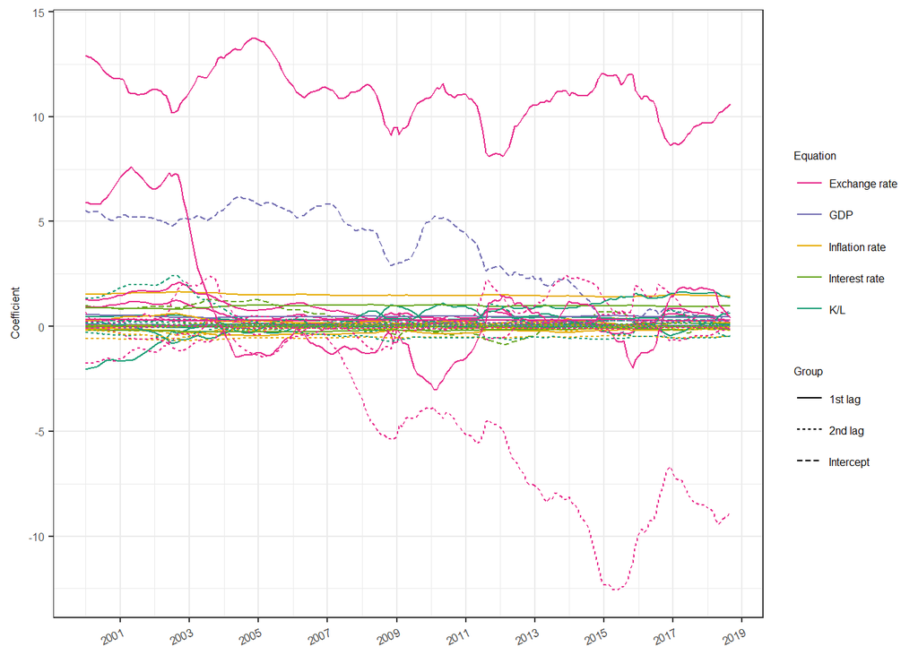

```r
Media_betas <- data.frame(Media_betas)
Datas <- seq(from = as.Date("2000-02-01"), to = as.Date("2018-10-01"), by = "1 month")

Media_betas$Data <- Datas

df2 <- melt(data = Media_betas, id.vars = "Data")

df2$Group <- ifelse(df2$variable == "X1" | df2$variable == "X2" | df2$variable == "X3" | df2$variable == "X4" | df2$variable == "X5", "Intercept",
                    ifelse(df2$variable == "X6" | df2$variable == "X7" | df2$variable == "X8" | df2$variable == "X9"  | df2$variable == "X10"
                            | df2$variable == "X11"  | df2$variable == "X12"  | df2$variable == "X13"  | df2$variable == "X14"  | df2$variable == "X15"
                            | df2$variable == "X16"  | df2$variable == "X17"  | df2$variable == "X18"  | df2$variable == "X19"  | df2$variable == "X20"
                            | df2$variable == "X21"  | df2$variable == "X22"  | df2$variable == "X23"  | df2$variable == "X24"  | df2$variable == "X25"
                            | df2$variable == "X26"  | df2$variable == "X27"  | df2$variable == "X28"  | df2$variable == "X29"  | df2$variable == "X30",
                           "1st lag", "2nd lag"))
df2$Group <- as.factor(df2$Group)

df2$Equation <- ifelse(df2$variable == "X1" | df2$variable == "X6" | df2$variable == "X11" | df2$variable == "X16" | df2$variable == "X21" |
                         df2$variable == "X26" | df2$variable == "X31" | df2$variable == "X36" | df2$variable == "X41" | df2$variable == "X46" |
                         df2$variable == "X51", "K/L",
                ifelse(df2$variable == "X2" | df2$variable == "X7" | df2$variable == "X12" | df2$variable == "X17" | df2$variable == "X22" |
                         df2$variable == "X27" | df2$variable == "X32" | df2$variable == "X37" | df2$variable == "X42" | df2$variable == "X47" |
                         df2$variable == "X52", "Inflation rate",
                ifelse(df2$variable == "X3" | df2$variable == "X8" | df2$variable == "X13" | df2$variable == "X18" | df2$variable == "X23" |
                         df2$variable == "X28" | df2$variable == "X33" | df2$variable == "X38" | df2$variable == "X43" | df2$variable == "X48" |
                         df2$variable == "X53", "GDP",
                ifelse(df2$variable == "X4" | df2$variable == "X9" | df2$variable == "X14" | df2$variable == "X19" | df2$variable == "X24" |
                         df2$variable == "X29" | df2$variable == "X34" | df2$variable == "X39" | df2$variable == "X44" | df2$variable == "X49" |
                         df2$variable == "X54", "Interest rate", "Exchange rate"))))
df2$Equation <- as.factor(df2$Equation)

cores <- brewer.pal(6, "Dark2")

p1 <- ggplot(df2, aes(Data, value, colour = Equation, group = variable, linetype = Group)) +
        geom_line(show.legend=T)+
        scale_y_continuous(name="Coefficient") +
        scale_colour_manual(values = c(cores[4], cores[3], cores[6], cores[5], cores[1]))+
        scale_x_date(date_breaks = "24 months", name = "Year", labels = date_format("%Y"))+
        theme_bw()
p1 <- p1 + theme(axis.text.x = element_text(angle=25, hjust = 1, size = 6), axis.title.x = element_blank(), axis.title.y = element_text(size = 6), legend.text = element_text(size=6), legend.title = element_text(size=6), axis.text.y = element_text(size=6))

p2 <- ggplot(df2, aes(Data, value, colour = Equation, group = variable)) +
        geom_line(show.legend=T)+
        scale_y_continuous(name="Coefficient") +
        scale_colour_manual(values = c(cores[4], cores[3], cores[6], cores[5], cores[1]))+
        scale_x_date(date_breaks = "24 months", name = "Year", labels = date_format("%Y"))+
        theme_bw()
p2 <- p2 + theme(axis.text.x = element_text(angle=25, hjust = 1, size = 6), axis.title.x = element_blank(), axis.title.y = element_text(size = 6), legend.text = element_text(size=6), legend.title = element_text(size=6), axis.text.y = element_text(size=6))

p3 <- ggplot(df2, aes(Data, value, colour = Group, group = variable)) +
        geom_line(show.legend=T)+
        scale_y_continuous(name="Coefficient") +
        scale_x_date(date_breaks = "24 months", name = "Year", labels = date_format("%Y"))+
        theme_bw()
p3 <- p3 + theme(axis.text.x = element_text(angle=25, hjust = 1, size = 6), axis.title.x = element_blank(), axis.title.y = element_text(size = 6), legend.text = element_text(size=6), legend.title = element_text(size=6), axis.text.y = element_text(size=6))

#pdf(file = "D:\\Onedrive - Aisha\\OneDrive\\Documentos\\Mestrado Economia\\Dissertação\\Texto final\\Figuras\\Resultados\\Coeficientes\\Fig-Coeff_all.pdf", width = 8, height = 3)
p1
```

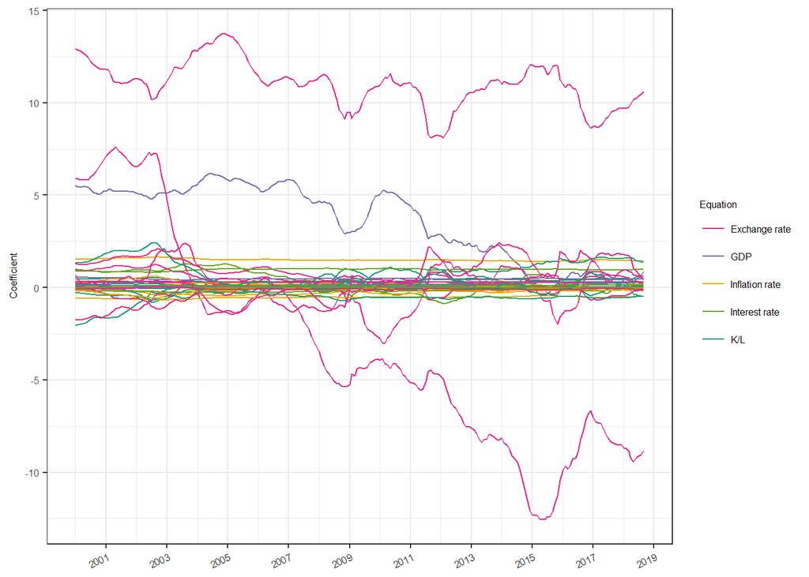

```r
#dev.off()

#pdf(file = "D:\\Onedrive - Aisha\\OneDrive\\Documentos\\Mestrado Economia\\Dissertação\\Texto final\\Figuras\\Resultados\\Coeficientes\\Fig-Coeff_equation.pdf", width = 10, height = 3)
p2
```

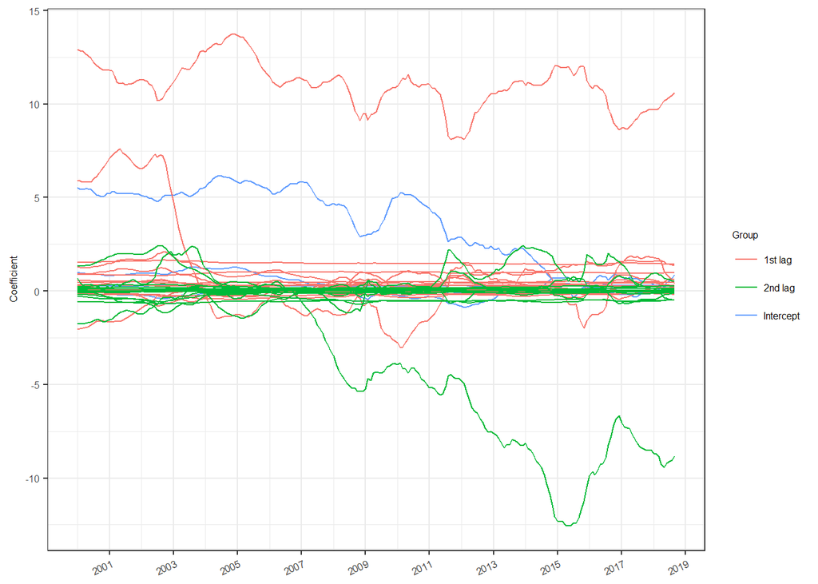

```r
#dev.off()

#pdf(file = "D:\\Onedrive - Aisha\\OneDrive\\Documentos\\Mestrado Economia\\Dissertação\\Texto final\\Figuras\\Resultados\\Coeficientes\\Fig-Coeff_group.pdf", width = 10, height = 3)
p3
```

```r
#dev.off()
```

## Credible Intervals of selected coefficients

### Saving the coefficients first

```r
# First lag coefficients of each variable in its own equation
beta_ct     <- Betas[6, ,]
beta_swap   <- Betas[24, ,]
beta_pib    <- Betas[18, ,]
beta_cambio <- Betas[30, ,]
beta_ipca   <- Betas[12, ,]

# First lag coefficients in the capital labor equation
beta_swap_ct    <- Betas[21, ,]
beta_pib_ct     <- Betas[16, ,]
beta_cambio_ct  <- Betas[26, ,]
beta_ipca_ct    <- Betas[11, ,]

# First lag coefficients in the swap equation
beta_ct_swap      <- Betas[9, ,]
beta_pib_swap     <- Betas[19, ,]
beta_cambio_swap  <- Betas[29, ,]
beta_ipca_swap    <- Betas[14, ,]

# First lag coefficients in the GDP equation
beta_ct_pib      <- Betas[8, ,]
beta_swap_pib    <- Betas[23, ,]
beta_cambio_pib  <- Betas[28, ,]
beta_ipca_pib    <- Betas[13, ,]

# First lag coefficients in the exchange rate equation
beta_ct_cambio    <- Betas[10, ,]
beta_swap_cambio  <- Betas[25, ,]
beta_pib_cambio   <- Betas[20, ,]
beta_ipca_cambio  <- Betas[15, ,]

# First lag coefficients in the inflation equation
beta_ct_ipca     <- Betas[7, ,]
beta_swap_ipca   <- Betas[22, ,]
beta_pib_ipca    <- Betas[17, ,]
beta_cambio_ipca <- Betas[27, ,]

##################
# SECOND LAG
##################

# Second lag coefficients of each variable in its own equation
beta_ct2     <- Betas[31, ,]
beta_swap2   <- Betas[49, ,]
beta_pib2    <- Betas[43, ,]
beta_cambio2 <- Betas[55, ,]
beta_ipca2   <- Betas[37, ,]

# Second lag coefficients in the capital labor equation
beta_swap_ct2    <- Betas[46, ,]
beta_pib_ct2     <- Betas[41, ,]
beta_cambio_ct2  <- Betas[51, ,]
beta_ipca_ct2    <- Betas[36, ,]

# Second lag coefficients in the swap equation
beta_ct_swap2      <- Betas[34, ,]
beta_pib_swap2     <- Betas[44, ,]
beta_cambio_swap2  <- Betas[54, ,]
beta_ipca_swap2    <- Betas[39, ,]

# Second lag coefficients in the GDP equation
beta_ct_pib2     <- Betas[33, ,]
beta_swap_pib2   <- Betas[48, ,]
beta_cambio_pib2 <- Betas[53, ,]
beta_ipca_pib2   <- Betas[38, ,]

# Second lag coefficients in the exchange rate equation
beta_ct_cambio2    <- Betas[35, ,]
beta_swap_cambio2  <- Betas[50, ,]
beta_pib_cambio2   <- Betas[45, ,]
beta_ipca_cambio2  <- Betas[40, ,]

# Second lag coefficients in the inflation equation
beta_ct_ipca2     <- Betas[32, ,]
beta_swap_ipca2   <- Betas[47, ,]
beta_pib_ipca2    <- Betas[42, ,]
beta_cambio_ipca2 <- Betas[52, ,]
```

### Saving the volatilities

```r
sd_ct       <- t(Todos_H[1, seq(from = 1, by = M., length.out = tempo-1), ])
sd_swap     <- t(Todos_H[4, seq(from = 4, by = M., length.out = tempo-1), ])
sd_pib      <- t(Todos_H[3, seq(from = 3, by = M., length.out = tempo-1), ])
sd_cambio   <- t(Todos_H[5, seq(from = 5, by = M., length.out = tempo-1), ])
sd_ipca     <- t(Todos_H[2, seq(from = 2, by = M., length.out = tempo-1), ])
```

### Some auxiliary information

I’m going to recycle my old code.

```r
# Stat.helper calculates que quantiles and organizes them in quantile 1, mean, quantile 3 given a vector z
stat.helper <- function(z) c(median(z), quantile(z, c(0.16, 0.84)))[c(2,1,3)]
stat.helper2 <- function(z) c(median(z), quantile(z, c(0.05, 0.25, 0.75, 0.95)))[c(2, 3, 1, 4, 5)]

# Color palette
#cbPalette <- c("#999999", "#E69F00", "#56B4E9", "#009E73", "#F0E442", "#0072B2", "#D55E00", "#CC79A7")

#cols1 <- cbPalette[c(2,4,2)]
#cols2 <- cbPalette[c(2,4,6)]
```

## Coefficient of each variable in its own equation

### Capital-labor ratio

```r
x1betact2  <- t(apply(beta_ct, 1, stat.helper2)) # First lag
x12        <- t(apply(sqrt(sd_ct), 2, stat.helper2)) # Variance
x1betact22 <- t(apply(beta_ct2, 1, stat.helper2)) # Second lag

df2 <- data.frame(Data2, x1betact2)
names(df2) <- c("Data", "p5", "p25", "media", "p75", "p95")

graph_beta_ct2 <- graph_IRF(df2, title. = "First lag coefficient of K/L in its own equation", ylabel. = "Coefficient", pos. = "below", color. = "blue", zeroline. = TRUE)

df2 <- data.frame(Data2, x1betact22)
names(df2) <- c("Data", "p5", "p25", "media", "p75", "p95")

graph_beta_ct_22 <- graph_IRF(df2, title. = "Second lag coefficient of K/L in its own equation", ylabel. = "Coefficient", pos. = "below", color. = "blue", zeroline. = TRUE)

df2 <- data.frame(Data2[2:length(Data2)], x12)
names(df2) <- c("Data", "p5", "p25", "media", "p75", "p95")

graph_sd_ct2 <- graph_IRF(df2, title. = "Volatility in the K/L equation", ylabel. = "Volatility", pos. = "below", color. = "blue")
```

### Inflation index

```r
x1betaipca2   <- t(apply(beta_ipca, 1, stat.helper2))     # First lag
x1betaipca22  <- t(apply(beta_ipca2, 1, stat.helper2))    # Second lag
x12           <- t(apply(sqrt(sd_ipca), 2, stat.helper2)) # Variance


df2 <- data.frame(Data2, x1betaipca2)
names(df2) <- c("Data", "p5", "p25", "media", "p75", "p95")

graph_beta_ipca2 <- graph_IRF(df2, title. = "First lag coefficient of Inflation index in its own equation", ylabel. = "Coefficient", pos. = "below", color. = "blue", zeroline. = TRUE)

df2 <- data.frame(Data2, x1betaipca22)
names(df2) <- c("Data", "p5", "p25", "media", "p75", "p95")

graph_beta_ipca_22 <- graph_IRF(df2, title. = "Second lag coefficient of Inflation index in its own equation", ylabel. = "Coefficient", pos. = "below", color. = "blue", zeroline. = TRUE)

df2 <- data.frame(Data2[2:length(Data2)], x12)
names(df2) <- c("Data", "p5", "p25", "media", "p75", "p95")

graph_sd_ipca2 <- graph_IRF(df2, title. = "Volatility in the inflation index equation", ylabel. = "Volatility", pos. = "below", color. = "blue")
```

### GDP

```r
x1betapib2   <- t(apply(beta_pib, 1, stat.helper2))     # First lag
x1betapib22  <- t(apply(beta_pib2, 1, stat.helper2))    # Second lag
x12           <- t(apply(sqrt(sd_pib), 2, stat.helper2)) # Variance


df2 <- data.frame(Data2, x1betapib2)
names(df2) <- c("Data", "p5", "p25", "media", "p75", "p95")

graph_beta_pib2 <- graph_IRF(df2, title. = "First lag coefficient of GDP variation in its own equation", ylabel. = "Coefficient", pos. = "below", color. = "blue", zeroline. = TRUE)

df2 <- data.frame(Data2, x1betapib22)
names(df2) <- c("Data", "p5", "p25", "media", "p75", "p95")

graph_beta_pib_22 <- graph_IRF(df2, title. = "Second lag coefficient of GDP variation in its own equation", ylabel. = "Coefficient", pos. = "below", color. = "blue", zeroline. = TRUE)

df2 <- data.frame(Data2[2:length(Data2)], x12)
names(df2) <- c("Data", "p5", "p25", "media", "p75", "p95")

graph_sd_pib2 <- graph_IRF(df2, title. = "Volatility in the GDP equation", ylabel. = "Volatility", pos. = "below", color. = "blue")
```

### Interest rate

```r
x1betaswap2   <- t(apply(beta_swap, 1, stat.helper2))     # First lag
x1betaswap22  <- t(apply(beta_swap2, 1, stat.helper2))    # Second lag
x12           <- t(apply(sqrt(sd_swap), 2, stat.helper2)) # Variance

df2 <- data.frame(Data2, x1betaswap2)
names(df2) <- c("Data", "p5", "p25", "media", "p75", "p95")

graph_beta_swap2 <- graph_IRF(df2, title. = "First lag coefficient of interest rate in its own equation", ylabel. = "Coefficient", pos. = "below", color. = "blue", zeroline. = TRUE)

df2 <- data.frame(Data2, x1betaswap22)
names(df2) <- c("Data", "p5", "p25", "media", "p75", "p95")

graph_beta_swap_22 <- graph_IRF(df2, title. = "Second lag coefficient of interest rate in its own equation", ylabel. = "Coefficient", pos. = "below", color. = "blue", zeroline. = TRUE)

df2 <- data.frame(Data2[2:length(Data2)], x12)
names(df2) <- c("Data", "p5", "p25", "media", "p75", "p95")

graph_sd_swap2 <- graph_IRF(df2, title. = "Volatility in the interest rate equation", ylabel. = "Volatility", pos. = "below", color. = "blue")
```

### Exchange rate

```r
x1betacambio2   <- t(apply(beta_cambio, 1, stat.helper2))     # First lag
x1betacambio22  <- t(apply(beta_cambio2, 1, stat.helper2))    # Second lag
x12           <- t(apply(sqrt(sd_cambio), 2, stat.helper2)) # Variance

df2 <- data.frame(Data2, x1betacambio2)
names(df2) <- c("Data", "p5", "p25", "media", "p75", "p95")

graph_beta_cambio2 <- graph_IRF(df2, title. = "First lag coefficient of exchange rate variation in its own equation", ylabel. = "Coefficient", pos. = "below", color. = "blue", zeroline. = TRUE)

df2 <- data.frame(Data2, x1betacambio22)
names(df2) <- c("Data", "p5", "p25", "media", "p75", "p95")

graph_beta_cambio_22 <- graph_IRF(df2, title. = "Second lag coefficient of exchange rate variation in its own equation", ylabel. = "Coefficient", pos. = "below", color. = "blue", zeroline. = TRUE)

df2 <- data.frame(Data2[2:length(Data2)], x12)
names(df2) <- c("Data", "p5", "p25", "media", "p75", "p95")

graph_sd_cambio2 <- graph_IRF(df2, title. = "Volatility in the exchange rate equation", ylabel. = "Coefficient", pos. = "below", color. = "blue")
```

Plotting everything together

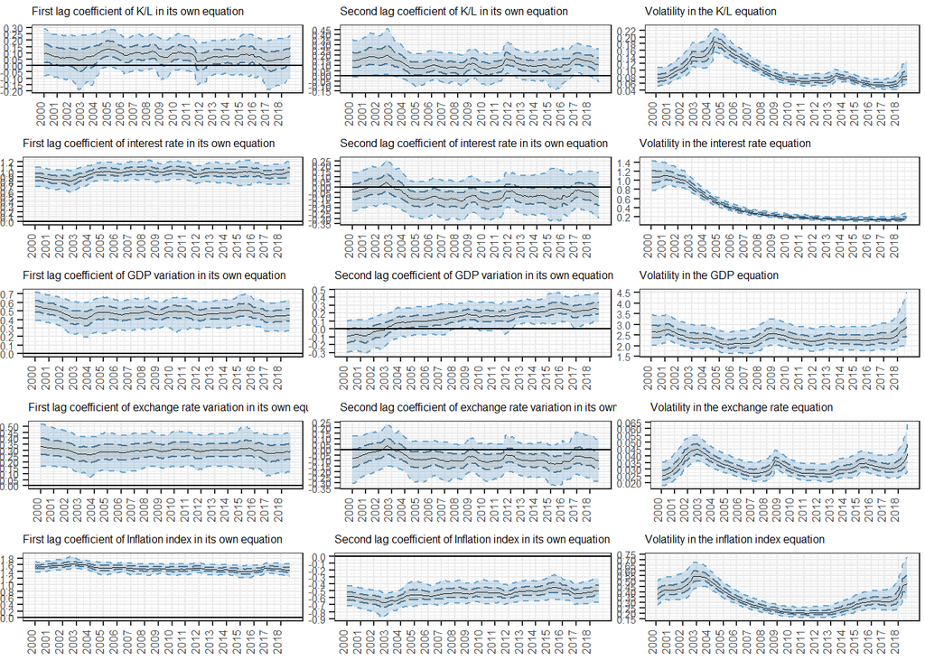

# Impulse response analysis

I’m using the functions from the `bvarsv` package, which implements (Primiceri 2005) TVP-VAR model. I addapted some stuff to accept my inputs from Matlab and some functionalities (specifically, the other ways to compute the IRF) are not currently being used. The codes are available [here](https://github.com/FK83/bvarsv/blob/master/R/bvarsv.R) and I’m following the documentation in (Krüger 2015).

## Auxiliary Functions

```r
# Auxiiary function
# So the beta at time t is a vector with 21 entries
# The first M entries are the intercepts
# What this function does is to organize the vector into a matrix M x 1 + M*p
# The first column has the intercepts
# The next columns have the coefficients for each variable, for the first lag and then for the second lag and so on
beta.reshapes <- cmpfun(function(beta, M, p){
  auxa <- matrix(rep(NA, length(beta)), nrow = M)
  auxa[1:M] <- beta[1:M] # Intercepts in the first column
  for (pp in 1:p){  # Fills auxa M columns at each iteration
    auxa[, ((pp-1)*M+2):(pp*M+1)] <- t(matrix(beta[(M+1+(pp-1)*(M^2)):(pp*(M^2)+M)], nrow = M)) # each line is one equation of the VAR, in order
  }
  return(auxa)
})


# Another auxiliary function
multmat <- cmpfun(function(mat, mult) {

  if(mult == 0){
    out <- diag(nrow(mat))
  } else if (mult == 1) {
    out <- mat
  } else {
    out <- mat
    for (c in 1:(mult-1)) out <- out %*% mat # for each period you multiply the matrix by itself, like in Koop's code
  }

  return(out)

})


# Another auxiliary function
FIRmats <- cmpfun(function(A, H.chol = NULL, nhor, orthogonal = TRUE) {
  # Dimensions
  M <- nrow(A) #it is the same M as before, don't know why redoing

  # AR matrices

  p <- ncol(A)/M # This is not an integer, so I'm not sure how this works. It will always be slighter higher than the real p.

  # Construct companion form matrices

  if (p > 1){

    # VAR matrices

    Ac <- matrix(0, M*p, M*p)
    Ac[1:M, ] <- A
    Ac[-(1:M), 1:(M*(p-1))] <- diag(M*(p-1))

  } else {

    Ac <- A
  }


  # Matrix with impulse responses
  # A matrix with rows equal to the number of variables and columns equal to the number of horizons multiplied by the variables
  Phi <- matrix(0, M, M*(nhor+1))
  for (s in 0:nhor){
    aux <- multmat(Ac, s)[1:M, 1:M]
    if (!is.null(H.chol)) aux <- aux %*% H.chol
    Phi[, (s*M+1):((s+1)*M)] <- aux
  }
  Phi
})


FIR <- cmpfun(function(fit, impulse.variable = 1, response.variable = 2, tempo = NULL, nhor = 20, scenario = 2) {

# Get coefficient draws (this part I need to pay attention to get the same thing from the Matlab)

# Using Primiceri's data, this is 21 lines (parameters) x 153 columns (periods) * 5000 repetitions
# The object is an array
# If we have 3 equations and 2 lags, this means that each equation has 7 parameters. The problem is to figure out their order, if it is per equation or per variable

################################
Beta.draws <- fit$Beta.draws   #
################################

nd         <- dim(Beta.draws)[3] # Number of repetitions

if(is.null(tempo)) tempo <- dim(Beta.draws)[2] # If the period to compute the IRF is not informed, then use the last period available

out <- matrix(0, nd, nhor + 1) # It is a matrix to store the IRF values

M <- fit$M # number of VAR equations
p <- fit$p # number of lags

# Get information from the VCV matrix
# I'm not sure who is H and who is A

# H.draws is 3 x 459 x 5000, where 459 is 153 x 3 (the number of time periods multiplied by the number of var variables)
# H.sel is a synmetric matrix, so I don't think it is Sigma, but by reading the help on the IRF, I think it is Sigma :|
#H.sel is 3, 3, 5000, so my guess here is that it takes all the replications from the time t of the variance in the measurement equation

H.sel <- fit$H.draws[,((tempo-1)*M+1):(tempo*M),]

# A.draws must be the same dimension H.draws
# A.sel is a superior triangular matrix, with the elements of the diagonal equal to one
# A.sel is 3, 3, 5000 and I have the same hypothesis as the H.sel, but I'm not sure if it is the covariance in the state transition equation

#A.sel <- fit$A.draws[,((tempo-1)*M+1):(tempo*M),]
A.sel <- NULL

if (scenario == 3){ # uses the average to compute the IFR
  # Compute mean of sigma over both time and MCMC draws, as made by Primiceri
  sig <- apply(exp(0.5*fit$logs2.draws), 1, mean)
  sig <- diag(sig)
} else {
  sig <- NULL
}

# Compute the impulse-response for each MC iteration

for (j in 1:nd){

  # Cholesky of VCV matrix, depending on specification
  if (scenario == 1){ # No orthogonalization at all
    H.chol <- NULL
  } else if (scenario == 2) {# Standard orthogonalization
    H.chol <- t(chol(H.sel[,,j]))
  } else if (scenario == 3) {# Orthogonalization as in Primiceri
    H.chol <- t(solve(A.sel[,,j])) %*% sig
  }

  ### I NEED TO TAKE IRFmat FUNCTION and BETA RESHAPE FUNCTIONS

  aux <- FIRmats(A = beta.reshapes(Beta.draws[,tempo,j], M, p)[,-1], H.chol = H.chol, nhor= nhor)
      aux <- aux[response.variable, seq(from = impulse.variable, by = M, length = nhor + 1)]
      out[j,] <- aux

}

list(contemporaneous = out[,1], irf = out[,-1])

})
```

```r
# Getting everything together in the same object
fit <- list(1)
fit$Beta.draws <- Betas
fit$p <- p.
fit$M <- M.
fit$H.draws <- Todos_H
```

# Computing the IRF

So, the technical details regarding the IRF computation can be seen [here](https://github.com/FK83/bvarsv/blob/master/bvarsv_Nov2015_website.pdf), but basically the IRF estimates the impact of an unitary shock of $\varepsilon_t$. The elements from $B_t$ and $\Sigma_t$ at the measurement equation are kept fixed in their $t$ values (which is indicated by the option `scenario = 2`. The ordering of the variables matters and must be justified on economic grounds. The graphs contains the 5%, 25%, 50%, 75% and 95% percentile lines, based on 10.000 posterior draws.

## Monetary shocks

### Over all variables, in the last period

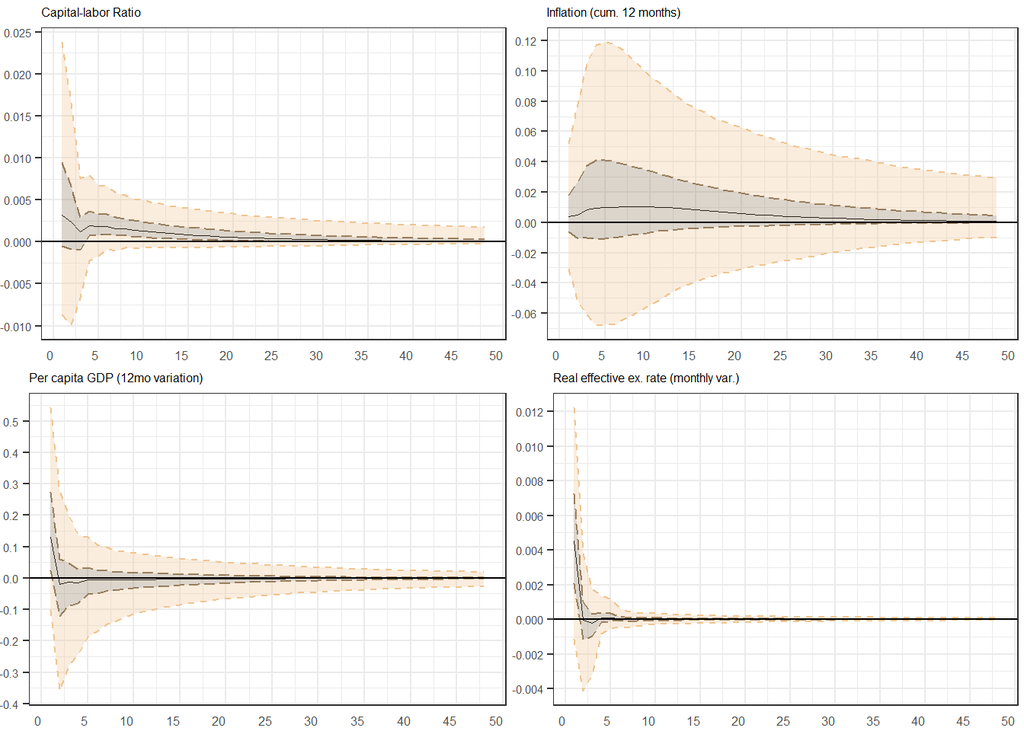

### In the capital labor ratio

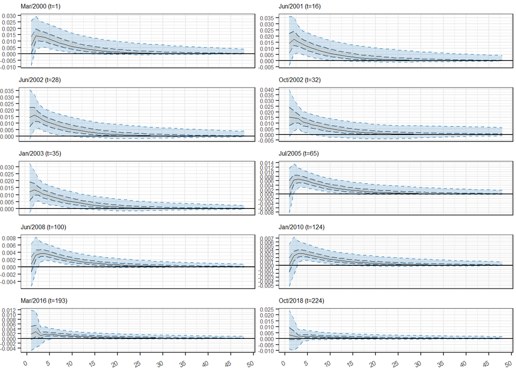

Monetary shocks impact on the capital labor ratio depending on the combination of central bank president and minister of finance.

Central Bank’s presidents:

- Arminio Fraga Neto - 4/3/1999 a 1/1/2003
- Henrique de Campos Meirelles - 1/1/2003 a 1/1/2011 $t=37$
- Alexandre Antonio Tombini - 1/1/2011 a 8/6/2016 $t=133$
- Ilan Goldfajn - 9/6/2016 - atual $t=198$

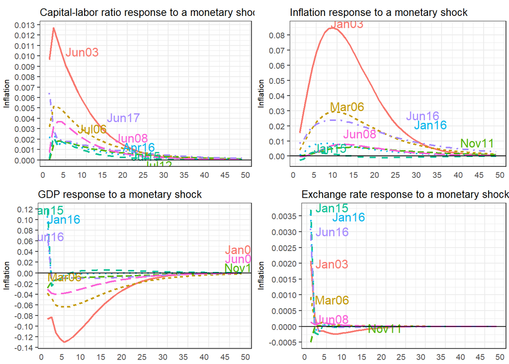

# Inflation shocks

### Efeito do Ipca na razão capital-trabalho

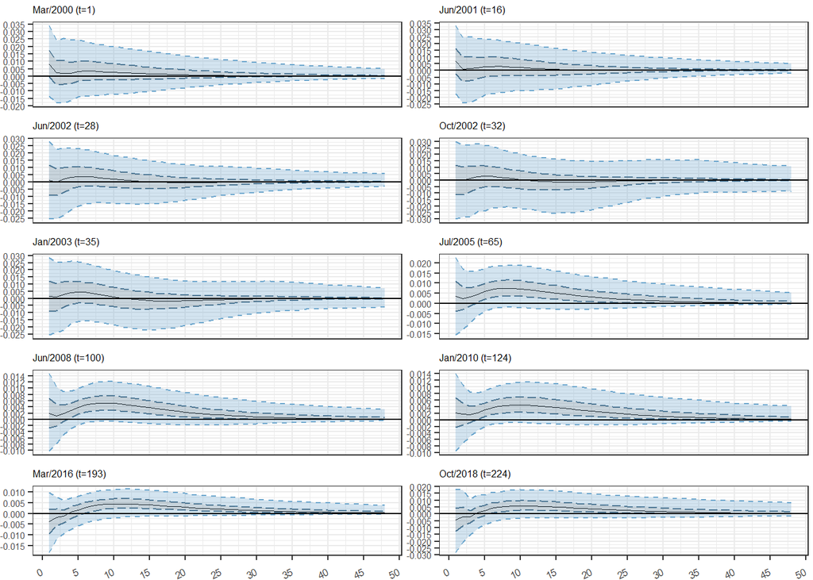

# References

Krüger, Fabian. 2015. “Bvarsv: An R Implementation of the Primiceri (2005) Model for Macroeconomic Time Series.” http://github.com/FK83/bvarsv/blob/master/bvarsv_Nov2015_website.pdf.

Primiceri, Giorgio E. 2005. “Time Varying Structural Vector Autoregressions and Monetary Policy.” *The Review of Economic Studies* 72 (3). Wiley-Blackwell: 821–52.